# Applications of Inference Frameworks: Linear Regression

## Frameworks for inference

1. Analytical
2. Maximum likelihood
3. Resampling
4. Bayesian

## For example…

1. Calibration curves
2. Metabolic rate vs. Body mass
3. Leaf area vs. Total rainfall

Continuous variable vs. continuous variable

## Linear regression

What values of \(\theta_1\) and \(\theta_2\) provide the best fit line through \(Y\) as a function of \(X\)?

\[Y = \theta_1 + \theta_2 X\]

[figure not shown]

- How do we estimate \(\theta_1\) and \(\theta_2\)?
- What is “best fit”?

## Generate data

Generate \(n=30\) random data points: \(X \sim \mathcal{N}(10, 1)\) and \(Y = 2.3 X + \epsilon\), where \(\epsilon \sim \mathcal{N}(1, 1)\):

```r
set.seed(4)
n <- 30
X <- rnorm(n, mean = 10, sd = 1)
Y <- 2.3 * X + rnorm(n, mean = 1, sd = 1)
M <- data.frame(X, Y)
M %>% head()
```

```
##           X        Y
## 1 10.216755 24.65200
## 2  9.457507 23.80420
## 3 10.891145 25.29542
## 4 10.595981 23.88857
## 5 11.635618 28.62305
## 6 10.689275 25.18081
```

## Generate data

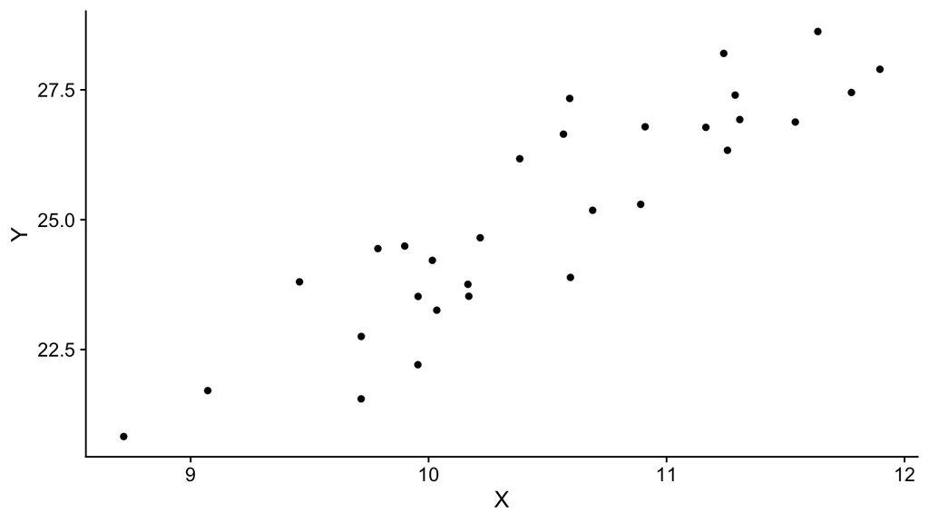

## Analytical solution

An infinite range of possible slopes (\(\theta_1\))

1. All pass through \(\left(\bar{X}, \bar{Y}\right)\).
2. Sum of the squared deviations vary continuously.
3. Only one value of \(\theta_1\) will minimize the SS.
   - The *Ordinary Least Squares* estimate

## Analytical calculation of \(\theta_1\)

\[\theta_1 = \frac{\sum\left(X_{i}-\bar{X}\right)\left(Y_{i}-\bar{Y}\right)}{\sum\left(X_{i}-\bar{X}\right)^{2}}\]

Numerator: Sum of the products of *X* and *Y*

Denominator: Sum of squares of *X*

## Analytical calculation of \(\theta_0\)

Because the OLS line must pass through \(\left(\bar{X},\bar{Y}\right)\):

\[\theta_0 = \bar{Y} - \theta_1 \bar{X}\]

## Assumptions of OLS

At each *X*, there is a normally distributed population of *Y* observations with a mean at the regression line

- The variance of all *Y* observations is equal.

Few assumptions are made about *X*

- *Is* measured without error
- Not that it is normal
- Not that it is randomly sampled
- Think about calibration curves. You set the *X* observations explicitly.

## Normally distributed population of *Y* observations

[figure not shown]

## Minimizing Sums of Squares

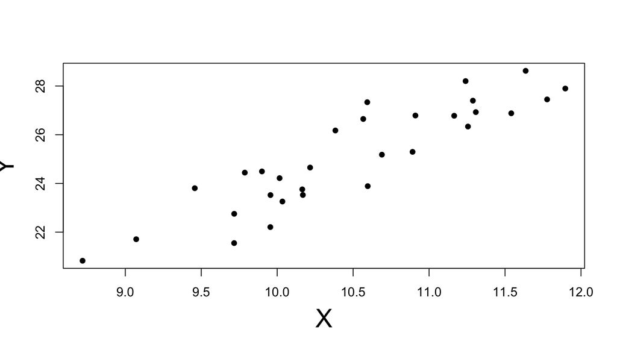

## Minimizing Sums of Squares

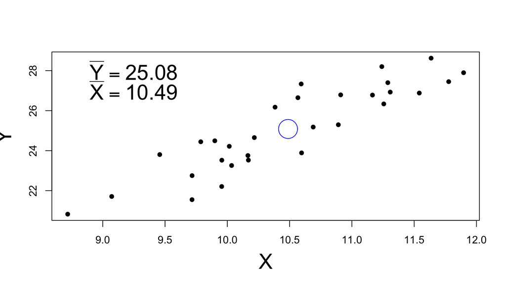

## Minimizing Sums of Squares

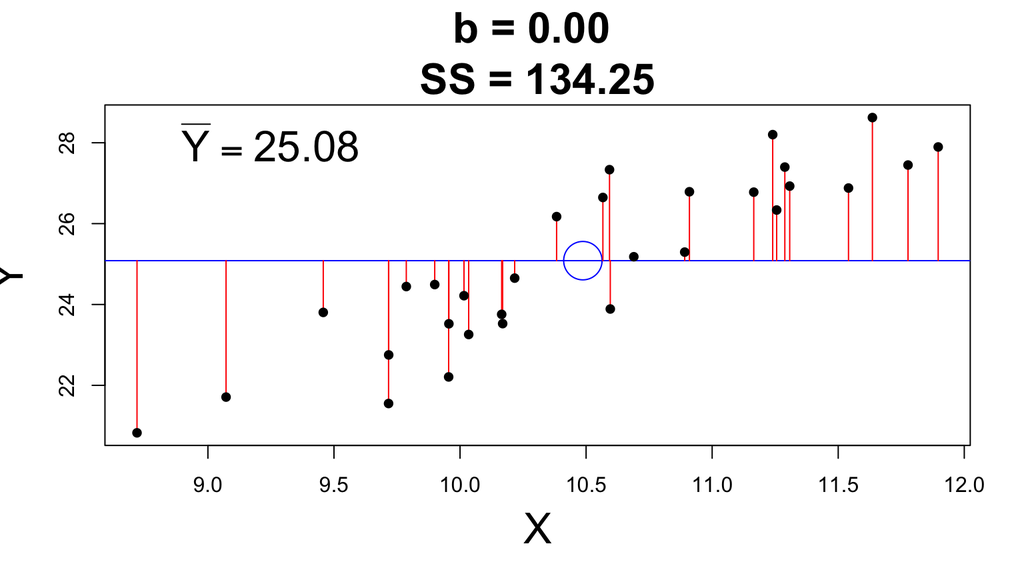

## Minimizing Sums of Squares

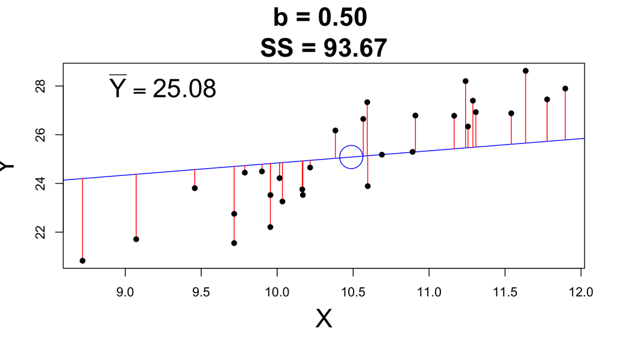

## Minimizing Sums of Squares

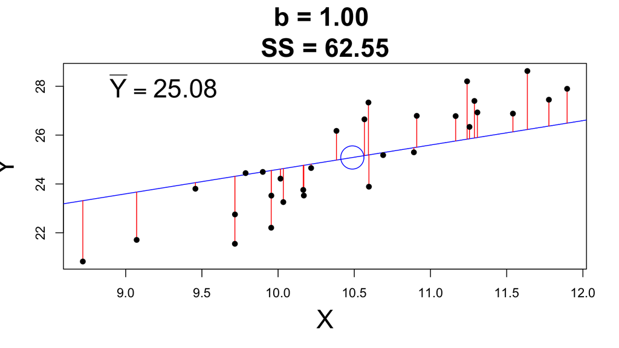

## Minimizing Sums of Squares

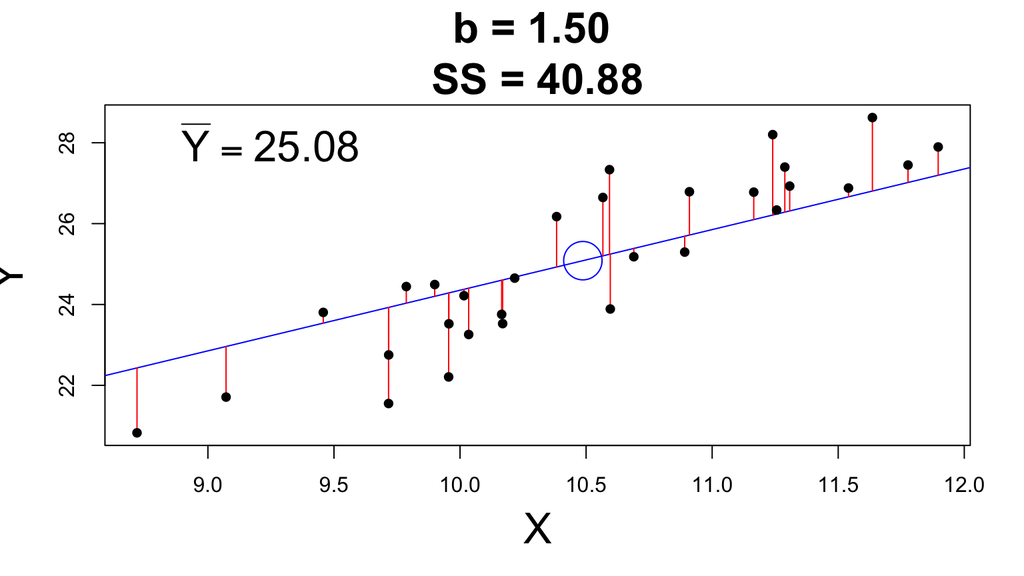

## Minimizing Sums of Squares

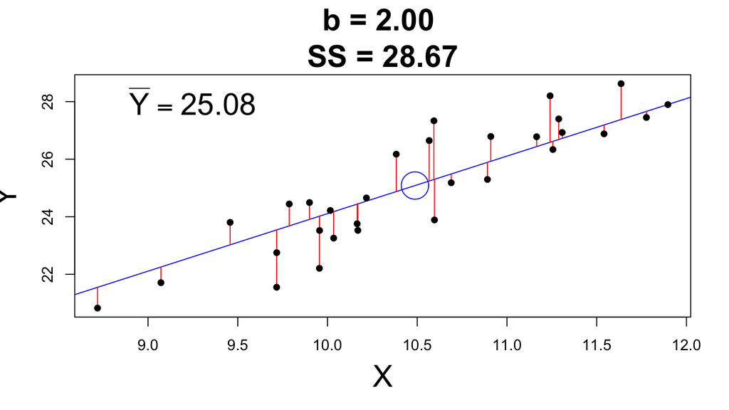

## Minimizing Sums of Squares

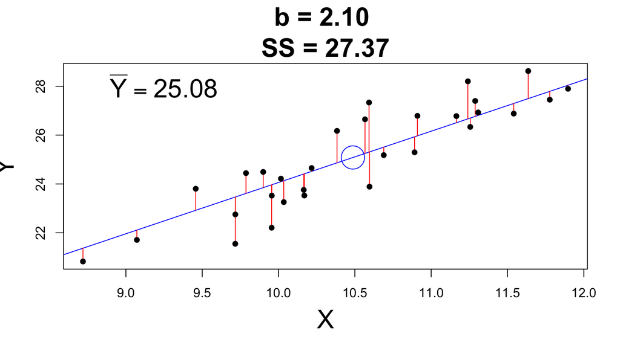

## Minimizing Sums of Squares

```r
# Iteratively find the minimum SS
theta_1 <- seq(-10, 10, by = 0.01)

# data.frame to hold output
SumSq <- data.frame(theta_1 = theta_1,
                    SS = numeric(length(theta_1)))
head(SumSq)
```

```
##   theta_1 SS
## 1  -10.00  0
## 2   -9.99  0
## 3   -9.98  0
## 4   -9.97  0
## 5   -9.96  0
## 6   -9.95  0
```

## Minimizing Sums of Squares

```r
# Iterate through slopes
for (ii in 1:nrow(SumSq)) {
  theta_1 <- SumSq$theta_1[ii]
  SumSq$SS[ii] <- ssPlot(X, Y, theta_1, do.plot = FALSE)
}

# Location of minimum SS
minSS.theta_1 <- SumSq$theta_1[which.min(SumSq$SS)]
minSS.SS <- SumSq$SS[which.min(SumSq$SS)]
```

## Minimizing Sums of Squares

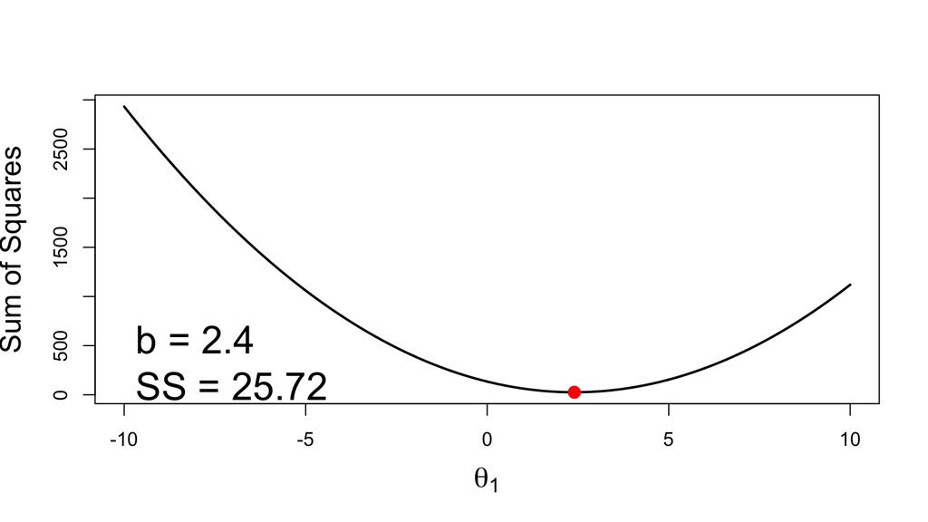

## Frameworks for inference

1. Analytical
2. Maximum likelihood
   - Minimizing the residual sum of squares is numerically equal to *maximizing* the model likelihood.
3. Resampling
4. Bayesian